# Objektorientierung Teil 1

Informatik II für Geodäsie (522.408, 522.409)  
Informatik 2 (GST.412UF, GST.413UF)

**Sebastian Strasser**

Institut für Geodäsie

21. März 2019

## Ziele

Ziel dieser Einheit ist es

- zu verstehen, was Objektorientierung bedeutet
- zu lernen, was Klassen, Objekte, Attribute, und Methoden sind
- Kapselung und deren Vorteile erklären zu können
- die Definition von Zugriffsrechten/Sichtbarkeiten zu verstehen
- einfache Klassen mit Attributen und Methoden zu implementieren

## Objektorientierte Programmierung

- Daten und deren Funktionen (Methoden) werden in einem Objekt zusammengefasst
- Kapselung nach außen, um Manipulation zu verhindern
- Objekte (auch Instanzen genannt) werden über Klassen definiert
- Klasse stellt formale Beschreibung über die Beschaffenheit eines Objekts dar
  - Welche Attribute/Eigenschaften hat das Objekt?
  - Über welche Methoden kann auf diese Attribute zugegriffen werden?

Objekte werden zur Laufzeit basierend auf Klassen ("Baupläne") erzeugt

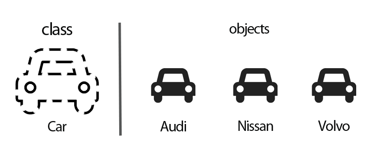

### Kapselung von Daten

- Zugriff auf Eigenschaften darf nur über Zugriffsmethoden erfolgen
- Zugriffsmethoden können enthalten
  - Plausibilitätstests (z.B. Distanz positiv?)
  - Datentypumwandlungen (z.B. datetime(2008, 1, 1) -> 54466)
  - Sonstige beliebige Berechnungen (z.B. Grad -> Radiant)
- Eigentliche Implementierung nach außen nicht sichtbar

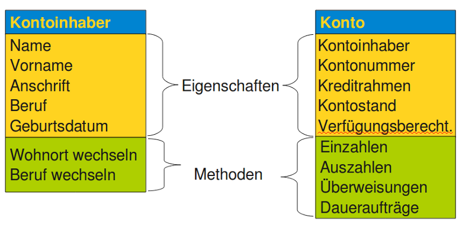

Beispiel:

- Kontostand kann nur über Methoden "Einzahlen" und "Auszahlen" geändert werden
- Anschrift kann sich nur über Methode "Wohnort wechseln" ändern

### Vererbung

- Klassen können auf anderen Klassen aufbauen
- Attribute und Methoden der Basisklasse(n) werden geerbt

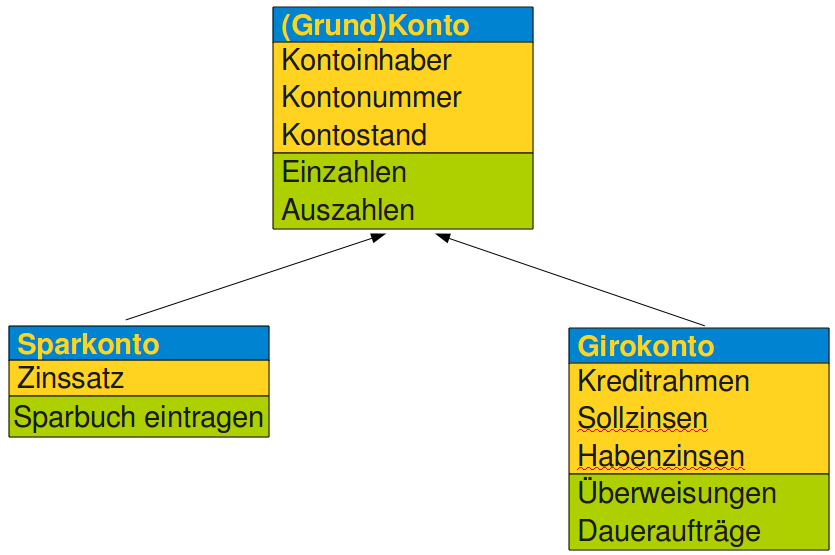

## Klassen in Python

Python besitzt viele integrierte Klassen, z.B. die Klasse `list`

```python
x = [2, 4, 8]
y = [10, "abc"]
print(x[1])
```

```
4
```

```python
x[1] = 100
x.append(42)
last = y.pop()
print(last)
```

```
abc
```

Die Variablen `x` und `y` sind zwei Objekte/Instanzen der Klasse `list`.

### Kapselung von Daten und Methoden

`pop` und `append` sind Methoden der Klasse `list`

- `pop` entnimmt der Liste das letzte Element und liefert es zurück
- `append` fügt der Liste am Ende ein Element hinzu

Zugriff auf den dahinterliegenden Speicher nur über eine definierte Schnittstelle

- Wir wissen nicht, wie die Klasse `list` die Daten im Speicher ablegt
- Wir müssen es auch nicht wissen, da wir über Methoden "indirekt" auf den Speicher zugreifen können

### Beispiel für minimale Klasse

```python
class Robot:
    pass

robotA = Robot() # create robot
robotB = Robot() # create robot
robotC = robotB  # set alias/reference

print(robotA == robotB)
print(robotB == robotC)
```

```
False
True
```

### Eigenschaften und Attribute

Python erlaubt das Erstellen von dynamischen Attributen

```python
class Robot:
    pass

robotA = Robot()
robotB = Robot()

robotA.name = "Bender"
robotA.year = 1999
robotB.name = "Marvin"
robotB.year = 1979

print(robotA.name)
```

```
Bender
```

Dynamische Attribute sind **keine** Attribute im Sinne der objektorientierten Programmierung, da sie unabhängig von der Klasse sind!

### Methoden

Methoden unterscheiden sich in zwei Punkten von Funktionen

- Methoden sind Funktionen, die innerhalb einer Klasse definiert sind
- Der erste Parameter einer Methode ist immer eine Referenz auf die Instanz, von der sie aufgerufen wird. (Üblicher Name: `self`)

```python
class Robot:
    def sayHello(self): # reference is passed as parameter 'self'
        print("Hallo")

robot = Robot()
robot.sayHello() # reference does not have to be passed manually
```

```
Hallo
```

Die Referenz auf die Instanz wird beim Aufruf automatisch übergeben.

### Instanzattribute

Methoden können auf Attribute der Instanz über die Referenz `self` zugreifen.

```python
class Robot:
    def sayHello(self):
        print("Hallo, ich bin " + self.name)

    def setName(self, name):
        self.name = name

robot = Robot()
robot.setName("Bender")
robot.sayHello()
```

```
Hallo, ich bin Bender
```

Das Attribut `name` existiert erst nach dem Aufruf der Methode `setName`.

### Die Methode `__init__` (vgl. Konstruktor)

Wie kann man sicherstellen, dass jede Instanz der Klasse ein bestimmtes Attribut besitzt?

Die "magische" Methode `__init__` wird automatisch nach der Erzeugung einer Instanz aufgerufen.

```python
class ExampleClass:
    def __init__(self):
        print("Methode __init__ wurde ausgeführt.")

example = ExampleClass()
```

```
Methode __init__ wurde ausgeführt.
```

```python
class Robot:
    def __init__(self, name, yearOfConstruction):
        self.name = name
        self.year = yearOfConstruction

    def sayHello(self):
        print("Hallo, ich bin " + self.name)

    def setName(self, name):
        self.name = name

robotA = Robot("Bender", 1999)
robotB = Robot("Marvin", 1979)
robotA.sayHello()
robotB.setName("Marvin, der paranoide Androide")
robotB.sayHello()
```

```
Hallo, ich bin Bender
Hallo, ich bin Marvin, der paranoide Androide
```

## Datenkapselung, -abstraktion und Geheimnisprinzip

Datenkapselung

- Schutz von Daten/Attributen vor dem unmittelbaren Zugriff
- Zugriff nur über Zugriffsmethoden
  - **get**-Funktion zum Lesen/Abfragen des Attributs
  - **set**-Funktion zum Schreiben/Verändern des Attributs

Geheimnisprinzip

- Verbergen von internen Informationen und Implementierungsdetails
- Nutzer der Klasse muss die Implementierung nicht kennen

Datenabstraktion = Datenkapselung + Geheimnisprinzip

Auf das Attribut `name` kann bisher direkt zugegriffen werden

```python
robot = Robot("Marvin", 1979)
robot.name = "Marvin, der paranoide Androide"
print(robot.name)
```

```
Marvin, der paranoide Androide
```

Korrekt im Sinne der Datenkapselung wäre:

```python
robot = Robot("Marvin", 1979)
robot.setName("Marvin, der paranoide Androide")
print(robot.getName())
```

Klasse `Robot` mit Zugriffsmethoden für Attribut `name`

```python
class Robot:
    def __init__(self, name, yearOfConstruction):
        self.setName(name)                        # use set method for attribute 'name'
        self.year = yearOfConstruction

    def sayHello(self):
        print("Hallo, ich bin " + self.getName()) # use get method for attribute 'name'

    def setName(self, name):
        self.name = name

    def getName(self):
        return self.name

robot = Robot("Marvin", 1979)
robot.setName("Marvin, der paranoide Androide")
print(robot.getName())
robot.sayHello()
```

```
Marvin, der paranoide Androide
Hallo, ich bin Marvin, der paranoide Androide
```

### Public, Protected und Private

Wie kann der Zugriff auf Attribute und Methoden geregelt werden?

3 Stufen an Zugriffsrechten: `public`, `protected`, `private`

Beispiel: Deine Mutter bestellt eine Pizza. Bei der Lieferung erwartet der Pizzabote die Bezahlung. Er soll aus der **Geldtasche deiner Mutter** bezahlt werden.

- Geldtasche ist `public`: Der Pizzabote nimmt sich das Geld direkt aus der Geldtasche.
- Geldtasche ist `protected`: Du nimmst das Geld aus der Geldtasche und gibst es dem Pizzaboten.
- Geldtasche ist `private`: Du holst deine Mutter, damit sie den Pizzaboten bezahlt, weil sie dir nicht erlaubt, Geld aus ihrer Geldtasche zu nehmen.

Unterscheidung in Python mittels Unterstrich vor dem Variablennamen

`name - public -` Zugriff von außen und innerhalb der Klasse  
`_name - protected -` Zugriff nur innerhalb Klasse und Unterklassen  
`__name - private -` Zugriff nur innerhalb Klasse

In Python sind dies nur **Konventionen**, die nicht erzwungen werden!

```python
class PrivacyExample():
    def __init__(self):
        self.publicAttribute     = "Ich bin öffentlich."
        self._protectedAttribute = "Ich bin geschützt."
        self.__privateAttribute  = "Ich bin privat."

example = PrivacyExample()
print(example.publicAttribute)
example.publicAttribute     = "Ich kann von außen geändert werden."
print(example._protectedAttribute)
example._protectedAttribute = "Ich kann, sollte aber nicht, von außen geändert werden!"
print(example.__privateAttribute)
example.__privateAttribute  = "Ich kann von außen nicht geändert werden."
```

```
Ich bin öffentlich.
Ich bin geschützt.
```

```
---------------------------------------------------------------------------
AttributeError                            Traceback (most recent call last)
<ipython-input-4-255c0a5a239c> in <module>
     10 print(example._protectedAttribute)
     11 example._protectedAttribute = "Ich kann, sollte aber nicht, von außen geändert werden!"
---> 12 print(example.__privateAttribute)
     13 example.__privateAttribute  = "Ich kann von außen nicht geändert werden."

AttributeError: 'PrivacyExample' object has no attribute '__privateAttribute'
```

Klasse `Robot` mit Zugriffsmethoden für **privates** Attribut `name`

```python
class Robot:
    def __init__(self, name, yearOfConstruction):
        self.setName(name)
        self.year = yearOfConstruction

    def sayHello(self):
        print("Hallo, ich bin " + self.getName())

    def setName(self, name):
        self.__name = name  # set private attribute 'name'

    def getName(self):
        return self.__name  # get private attribute 'name'

robot = Robot("Marvin", 1979)
robot.setName("Marvin, der paranoide Androide")
print(robot.getName())
robot.sayHello()
```

```
Marvin, der paranoide Androide
Hallo, ich bin Marvin, der paranoide Androide
```

### Die Methode `__del__` (vgl. Destruktor)

- Die magische Methode `__del__` wird vor der Zerstörung einer Instanz aufgerufen.
- Kann für eventuell notwendige Aufräumarbeiten (z.B. Speicher) verwendet werden.
- Wird nur aufgerufen, falls es keine weitere Referenz auf diese Instanz gibt.

```python
class Robot:
    def __init__(self, name):
        self.name = name
        print(self.name + " wurde erschaffen!")

    def __del__(self):
        print (self.name + " wurde zerstört!")

robotA = Robot("Bender")  # create instance
robotB = Robot("Marvin")  # create instance
robotC = robotB           # set reference
del robotA
del robotB
```

```
Bender wurde erschaffen!
Marvin wurde erschaffen!
Bender wurde zerstört!
```

## Zusammenfassung

- Daten und deren Methoden werden zu Objekten zusammengefasst
- Klasse definiert Struktur, Objekt instanziert Klasse
- Kapselung erlaubt Zugriffskontrolle und verbirgt Implementierung
- Es gibt drei Stufen: `public, protected, private`
- Magische Methoden `__init__` und `__del__` werden beim Erstellen/Löschen eines Objekts aufgerufen
- Erster Parameter einer Methode ist eine Referenz auf das Objekt selbst